# Zadaća 1

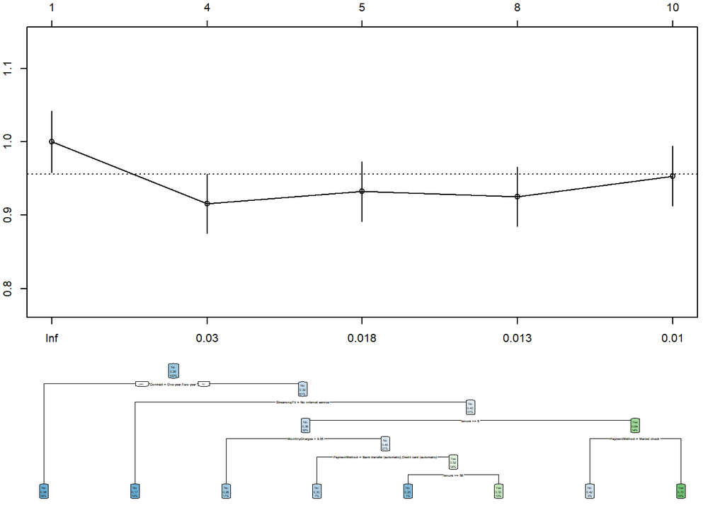

```r
#odredjivanje cp
plotcp(tree_information)

#smanjenje broja cvorova
pruned_tree_information<-prune(tree_information, cp = 0.013)
rpart.plot(pruned_tree_information)
```

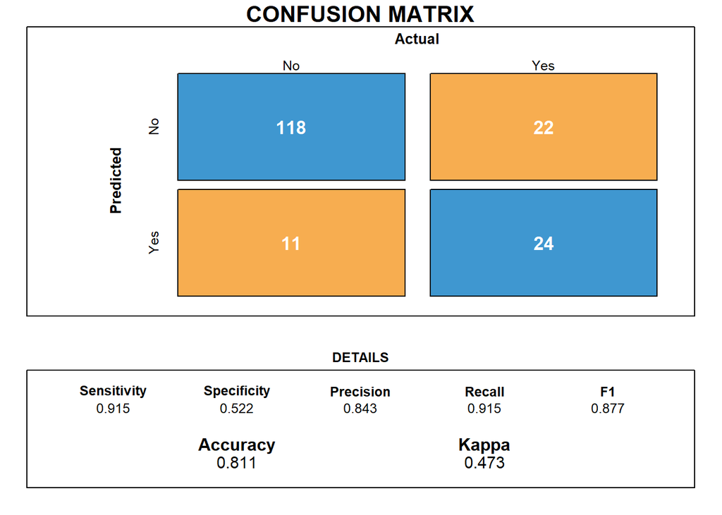

```r
#kreiranje konfuzijske matrice za novo stablo
library(caret)
prediction <- predict(pruned_tree_information, newdata = subset(podaci_test, select = -c(Churn)))
prediction<-prediction[,1]
class_prediction <-ifelse(prediction > 0.50,"No","Yes")
class_prediction<-factor(class_prediction, levels=levels(podaci_test$Churn))

cm<-confusionMatrix(data=class_prediction, reference = podaci_test$Churn)
draw_confusion_matrix(cm)
```

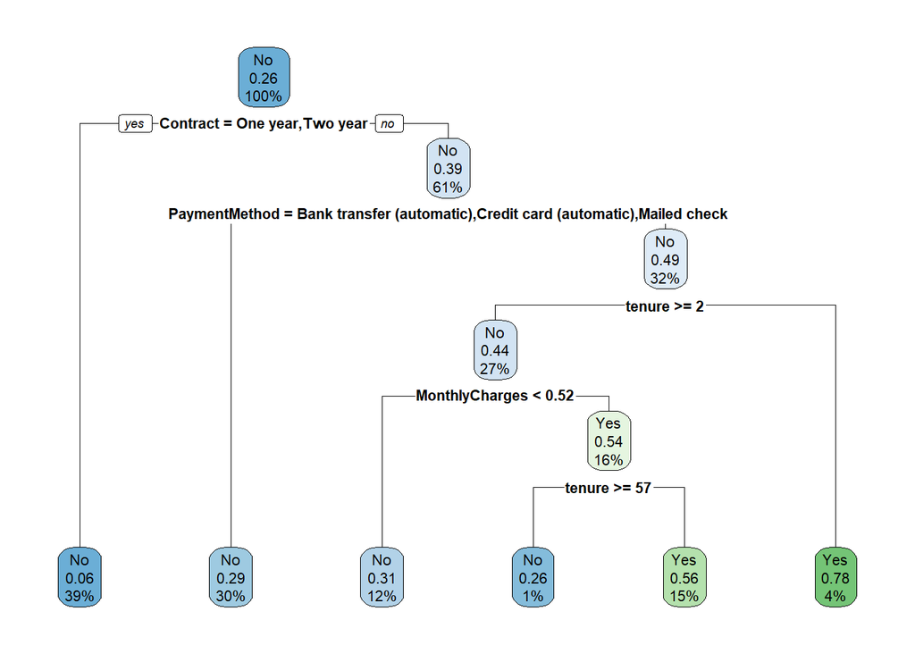

```r
#gini kriterij


#kreiranje stabla odlucivanja
tree_gain <- rpart(formula = Churn ~ .,
method = "class",
data = podaci_train)

#crtanje stabla odlucivanja
rpart.plot(tree_gain)
```

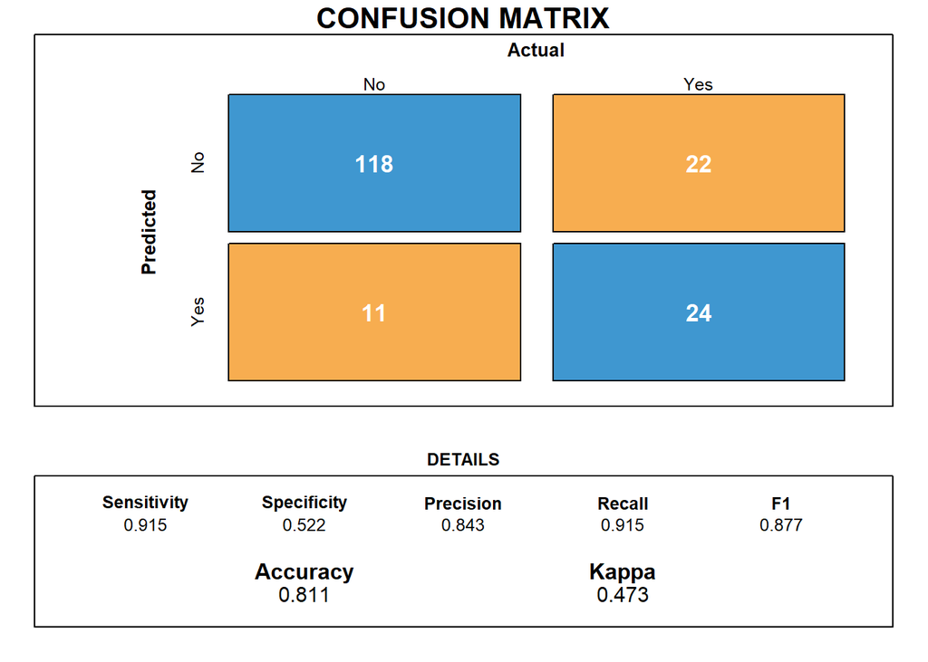

```r
#kreiranje konfuzijske matrice
prediction_gain <- predict(tree_gain, newdata = subset(podaci_test, select = -
c(Churn)))
prediction_gain<-prediction_gain[,1]
class_prediction <-ifelse(prediction > 0.50,"No","Yes")
class_prediction<-factor(class_prediction, levels=levels(podaci_test$Churn))

cm_gain<-confusionMatrix(data=class_prediction, reference = podaci_test$Churn)

draw_confusion_matrix(cm_gain)
```

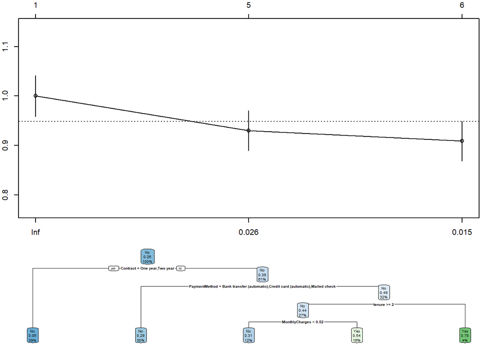

```r
#odredjivanje cp
plotcp(tree_gain)

#smanjenje broja cvorova
pruned_tree_gain<-prune(tree_gain, cp = 0.031)
rpart.plot(pruned_tree_gain)
```

```r
#kreiranje nove konfuzijske matrice
prediction_gain <- predict(pruned_tree_gain, newdata = subset(podaci_test, select = -c(Churn)))
prediction_gain<-prediction_gain[,1]
class_prediction <-ifelse(prediction > 0.50,"No","Yes")
class_prediction<-factor(class_prediction, levels=levels(podaci_test$Churn))

cm_gain<-confusionMatrix(data=class_prediction, reference = podaci_test$Churn)
```

```r
#C5.0 model klasifikacije
```

### b)

Implementirati predikcijske modele pod a) sa metodama:

- holdouta sa različitim podjelama na trening i testni podskup podataka;
- - k-fold unakrsne validacije sa različitim vrijednostima parametra k;
- k-fold bootstrapinga sa različitim vrijednostima parametra k.

Analizirati koja je metoda je dala najbolja poboljšanja performansi klasifikatora.

```r
#holdout
```

```r
#k-fold unakrsne validacije
```

```r
#k-fold bootstraping
```

### c)

Analizirati balansiranost podataka. Ukoliko set podataka nije balansiran, obavezno primijeniti neku od metoda za balansiranje seta podataka (oversampling ili undersampling) i izgraditi predikcijske modele iskazane pod a).

Analizirati koja metoda je dala najbolja poboljšanja performansi klasifikatora.

### d)

Izgraditi sljedeće modele korištenjem ansambl tehnika za unaprjeđenje tačnosti klasifikacije:

- bagging model;
- boosting model (uz korištenje AdaBoost metode);
- random forest model.

```r
#bagging model
```

```r
#boosting model
```

```r
#random forest model
```

## Zadatak 3. (Testiranje najboljeg modela)

Odabrati najbolji od svih kreiranih modela klasifikacije iz zadatka 2 i izvršiti njegovu evaluaciju nad testnim podskupom podataka za odgovarajuću nastavnu grupu:

- za grupe 1, 2 i 3 koristiti će se set podataka customer_data_test.csv;
- za grupe 4, 5 i 6 koristiti će se set podataka weather_data_test.csv.

Dokumentovati dobivene rezultate. Da bi ovaj zadatak bio bodovan, potrebno je ispuniti sljedeće uslove:

- Tačnost veća od 0.75
- F1-mjera veća od 0.65
- Kappa statistika veća od 0.25
- Osjetljivost veća od 0.70
- Specifičnost veća od 0.75

Ukoliko odabrani model ne ispunjava sve uslove, neophodno je ponoviti i dokumentovati proces iz zadataka 1 i 2 dok se ne dobije model koji ispunjava tražene uslove. Bodovanje ove aktivnosti je u okviru bodova za zadatak 2.

```r
podaci_testni <- read.csv("customer_data_test.csv", fileEncoding = 'UTF-8')

#faktorizacija kategorickih varijabli
podaci_testni$gender <- factor(podaci_testni$gender)
podaci_testni$Dependents <- factor(podaci_testni$Dependents)
podaci_testni$PhoneService <- factor(podaci_testni$PhoneService)
podaci_testni$MultipleLines <- factor(podaci_testni$MultipleLines)
podaci_testni$InternetService <- factor(podaci_testni$InternetService)
podaci_testni$StreamingMovies <- factor(podaci_testni$StreamingMovies)
podaci_testni$StreamingTV <- factor(podaci_testni$StreamingTV)
podaci_testni$Contract <- factor(podaci_testni$Contract)
podaci_testni$PaymentMethod <- factor(podaci_testni$PaymentMethod)
podaci_testni$Churn <- factor(podaci_testni$Churn)
```

## Zadatak 4 (Pravilo-bazirana klasifikacija)

Izgraditi sljedeće pravilo-bazirane modele klasifikacije:

- 1R model odlučivanja;
- RIPPER model odlučivanja.

Izvršiti treniranje i evaluaciju ovih modela na isti način kao u zadatku 2, a zatim i njihovu evaluaciju nad testnim podskupom podataka na isti način kao u zadatku 3.

Dokumentovati dobivene rezultate na isti način kao u prethodnim zadacima.

Da bi ovaj zadatak bio bodovan, potrebno je ispuniti sljedeće uslove:

- Tačnost veća od 0.70
- Obuhvat veći od 0.80

Prikazati skup pravila koji dovodi do ispunjenosti ova dva uslova.

```r
metrike_oner <- function(model, podaci)
{
 feature <- model$feature
 target <- model$target
 rules <- model$rules
 coverage <- 0

 for (i in 1 : length(rules))
 {
 pravilo <- names(rules[i])
 rezultat <- unlist(rules[i])
 subset <- podaci[podaci[[feature]] == pravilo, ]
 coverage <- nrow(subset) / nrow(podaci)
 correct <- subset[subset[[target]] == rezultat, ]
 accuracy <- nrow(correct) / nrow(subset)
 cat("Pravilo: IF", pravilo, "THEN", rezultat, ", pokrivenost:",
coverage, ", tačnost:", accuracy, "\n")
 }
}
```

```r
#1R model odlučivanja
library(OneR)
model <- OneR(podaci_train)
summary(model)
```

```
##
## Call:
## OneR.data.frame(x = podaci_train)
##
## Rules:
## If gender = Female then Churn = No
## If gender = Male   then Churn = No
##
## Accuracy:
## 1201 of 1629 instances classified correctly (73.73%)
##
## Contingency table:
##      gender
## Churn Female  Male  Sum
##   No   * 609 * 592 1201
##   Yes    219   209  428
##   Sum    828   801 1629
## ---
## Maximum in each column: '*'
##
## Pearson's Chi-squared test:
## X-squared = 0.011517, df = 1, p-value = 0.9145
```

```r
metrike_oner(model, podaci_train)
```

[output not shown]

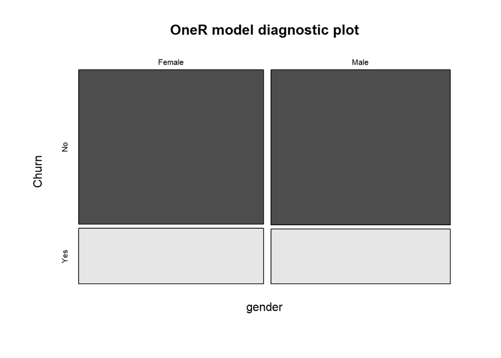

```r
plot(model)
```

```r
prediction <- predict(model, podaci_test)
cm <- confusionMatrix(data = prediction, reference =podaci_test$Churn)
```

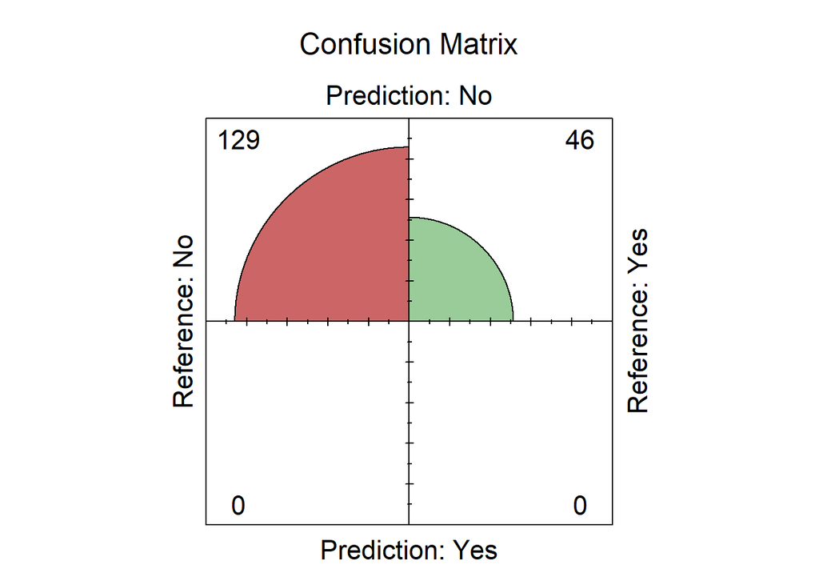

```r
fourfoldplot(cm$table, color = c("#99CC99", "#CC6666"),
conf.level = 0, margin = 1, main = "Confusion Matrix")
```

```r
prediction <- predict(model, podaci_testni)
cm <- confusionMatrix(data = prediction, reference =podaci_testni$Churn)
```

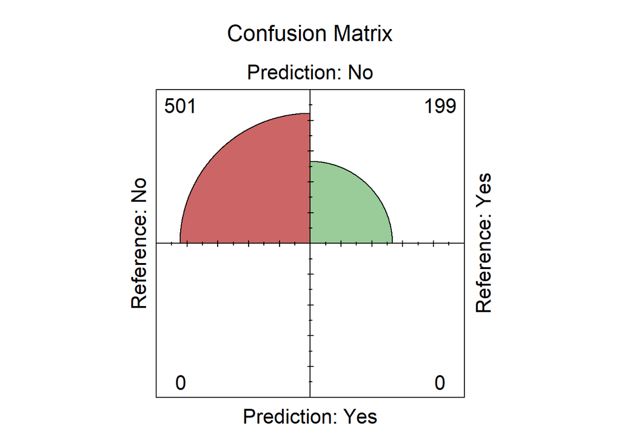

```r
fourfoldplot(cm$table, color = c("#99CC99", "#CC6666"),
conf.level = 0, margin = 1, main = "Confusion Matrix")
```

```r
#RIPPER model odlučivanja

library(rJava)
library(RWeka)
model <- JRip(formula = Churn ~ ., data = podaci_train)
summary(model)
```

```
##
## === Summary ===
##
## Correctly Classified Instances        1268               77.8392 %
## Incorrectly Classified Instances       361               22.1608 %
## Kappa statistic                          0.3759
## Mean absolute error                      0.3303
## Root mean squared error                  0.4064
## Relative absolute error                 85.2395 %
## Root relative squared error             92.3417 %
## Total Number of Instances             1629
##
## === Confusion Matrix ===
##
##     a    b   <-- classified as
##  1076  125 |    a = No
##   236  192 |    b = Yes
```

```r
model
```

```
## JRIP rules:
## ===========
##
## (Contract = Month-to-month) and (tenure <= 17) and (MonthlyCharges >= 0.451693) => Churn=Yes (283.0/114.0)
## (Contract = Month-to-month) and (PaymentMethod = Electronic check) and (MonthlyCharges >= 0.603586) and (MonthlyCharges <= 0.664343) => Churn=Yes (34.0/11.0)
##  => Churn=No (1312.0/236.0)
##
## Number of Rules : 3
```

```r
library(pROC)
prediction <- predict(model, podaci_test, type = "prob")
roc <- roc(podaci_test$Churn, prediction[, 2], percent = TRUE)
```

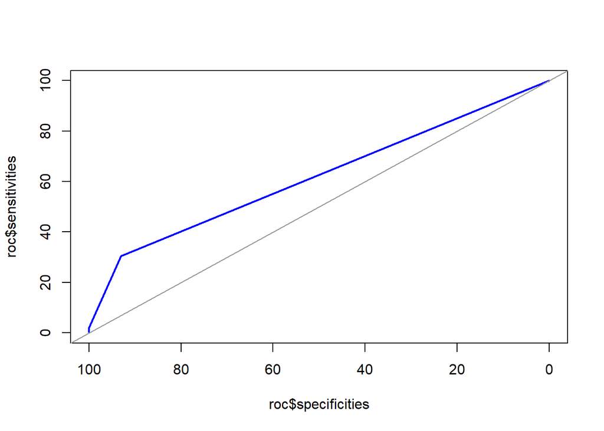

```r
plot(roc$specificities, roc$sensitivities, type="l", lwd = 2, col =
"blue", xlim = c(100, 0), ylim = c(0, 100))
abline(coef = c(100, -1), col = "gray60")
```

```r
prediction <- predict(model, podaci_testni, type = "prob")
roc <- roc(podaci_testni$Churn, prediction[, 2], percent = TRUE)
```

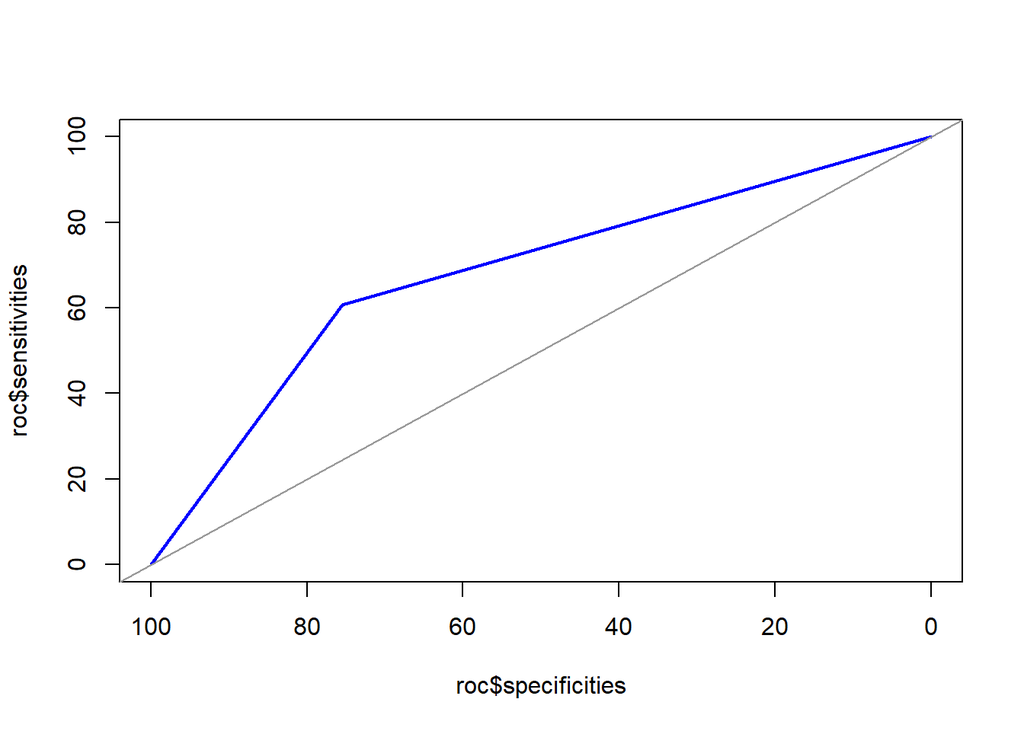

```r
plot(roc$specificities, roc$sensitivities, type="l", lwd = 2, col =
"blue", xlim = c(100, 0), ylim = c(0, 100))
abline(coef = c(100, -1), col = "gray60")
```